# Lab 04 - La Quinta is Spanish for next to Denny’s, Pt. 1

Jackie Budka

10/8/2021

### Load packages and data

```r
library(tidyverse)
library(dsbox)
library(sp)
library(rworldmap)
library(maps)
library(rgeos)
library(maptools)
library(gapminder)
library(revgeo)
library(dplyr)
library(ggplot2)
library(magrittr)
library(sf)
library(rnaturalearth)
library(leaflet)
library(usmap)
library(rgdal)
library(geosphere)
```

```r
states <- read_csv("U:/DataScience/ds241/states.csv")
```

### Exercise 1

```r
dn_ak <- dennys %>%
  filter(state == "AK")
nrow(dn_ak)
```

```
[1] 3
```

There are 3 Denny’s in Alaska.

### Exercise 2

```r
lq_ak <- laquinta %>%
  filter(state == "AK")
nrow(lq_ak)
```

```
[1] 2
```

There are 2 La Quinta’s in Alaska

### Exercise 3

We need to calculate 6 distances. These are the distances between each Denny’s and each La Quinta.

```r
# adapted from this solution on stack exchange https://stackoverflow.com/questions/32363998/function-to-calculate-geospatial-distance-between-two-points-lat-long-using-r
lq_ak_coord <- lq_ak %>%
select(longitude,latitude)
dn_ak_coord <- dn_ak %>%
  select(longitude,latitude)
distm(dn_ak_coord, lq_ak_coord, fun = distHaversine)
```

```
           [,1]       [,2]
[1,]   2037.218 416496.680
[2,]   6005.073 414116.254
[3,] 420349.181   5203.104
```

```r
dn_lq_ak <- full_join(dn_ak, lq_ak, by = "state")
dn_lq_ak
```

| address.x | city.x | state | zip.x | longitude.x | latitude.x | establishment.x | address.y | city.y | zip.y | longitude.y | latitude.y | establishment.y |
| --- | --- | --- | --- | --- | --- | --- | --- | --- | --- | --- | --- | --- |
| 2900 Denali | Anchorage | AK | 99503 | -149.8767 | 61.1953 | Denny's | 3501 Minnesota Dr. | \nAnchorage | 99503 | -149.9119 | 61.18843 | La Quinta |
| 2900 Denali | Anchorage | AK | 99503 | -149.8767 | 61.1953 | Denny's | 4920 Dale Rd | \nFairbanks | 99709 | -147.8660 | 64.82426 | La Quinta |
| 3850 Debarr Road | Anchorage | AK | 99508 | -149.8090 | 61.2097 | Denny's | 3501 Minnesota Dr. | \nAnchorage | 99503 | -149.9119 | 61.18843 | La Quinta |
| 3850 Debarr Road | Anchorage | AK | 99508 | -149.8090 | 61.2097 | Denny's | 4920 Dale Rd | \nFairbanks | 99709 | -147.8660 | 64.82426 | La Quinta |
| 1929 Airport Way | Fairbanks | AK | 99701 | -147.7600 | 64.8366 | Denny's | 3501 Minnesota Dr. | \nAnchorage | 99503 | -149.9119 | 61.18843 | La Quinta |
| 1929 Airport Way | Fairbanks | AK | 99701 | -147.7600 | 64.8366 | Denny's | 4920 Dale Rd | \nFairbanks | 99709 | -147.8660 | 64.82426 | La Quinta |

…

### Exercise 4

There are 6 observations in the new dn_lq_ak data frame.

```r
names(dn_lq_ak)
```

```
 [1] "address.x"       "city.x"
 [3] "state"           "zip.x"
 [5] "longitude.x"     "latitude.x"
 [7] "establishment.x" "address.y"
 [9] "city.y"          "zip.y"
[11] "longitude.y"     "latitude.y"
[13] "establishment.y"
```

…

### Exercise 5

Mutate.

```r
haversine <- function(long1, lat1, long2, lat2, round = 3) {
  # convert to radians
  long1 = long1 * pi / 180
  lat1  = lat1  * pi / 180
  long2 = long2 * pi / 180
  lat2  = lat2  * pi / 180

  R = 6371 # Earth mean radius in km

  a = sin((lat2 - lat1)/2)^2 + cos(lat1) * cos(lat2) * sin((long2 - long1)/2)^2
  d = R * 2 * asin(sqrt(a))

  return( round(d,round) ) # distance in km
}
```

…

### Exercise 6

```r
dn_lq_ak <- dn_lq_ak %>%
mutate(distance = haversine(longitude.x, latitude.x, longitude.y, latitude.y, round = 2))
```

…

### Exercise 7

```r
dn_lq_ak_mindist <- dn_lq_ak %>%
  group_by(address.x) %>%
  summarise(closest = min(distance))
```

…

### Exercise 8

…

### Exercise 9

```r
dennys3 <- dennys %>%
  count(state) %>%
  inner_join(states, by = c("state" = "abbreviation"))
laquinta5 <- laquinta3 %>%
  count(state)%>%
  inner_join(states, by = c("state" = "abbreviation"))
```

California, Texas, and Florida have the most Denny’s and Delaware, DC, and Vermont have the fewest. This makes sense becauase the states with the most are some of the most populated states and the ones with the fewest are some of the least populated.

Texas, Florida, and California have the most La Quintas and Maine, Alaska, and New Hampshire have the fewest. This also makes sense because the ones with the most are the most populated states and the ones with the least are some of the least populated states. …

### Exercise 10

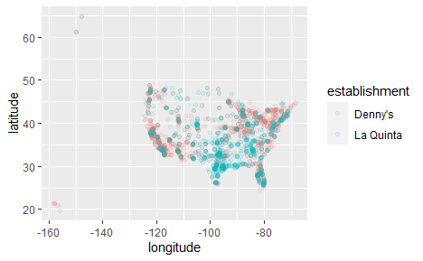

```r
dennys_per_sqm <- dennys3 %>%
  mutate(location_per_sqm = n/(area/1000))

laquintas_per_sqm <- laquinta5 %>%
  mutate(location_per_sqm = n/(area/1000))

dennys4 <- dennys %>%
  mutate(establishment = "Denny's")
laquinta4 <- laquinta3 %>%
  mutate(establishment = "La Quinta")

dn_lq <- bind_rows(dennys4, laquinta4)

ggplot(dn_lq, mapping = aes(x = longitude, y = latitude, color = establishment)) +
  geom_point(alpha = 0.1)
```

```r
NA
NA
```

DC, Rhode Island, and California had the most Denny’s per square mile. Rhode Island, Florida, and Connecticut had the most La Quintas per square mile. …

### Exercise 11

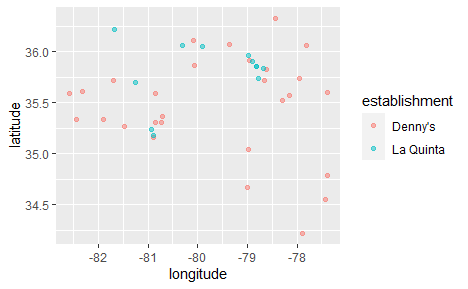

```r
MainStates <- map_data("state")
StatePopulation <- read.csv("https://raw.githubusercontent.com/ds4stats/r-tutorials/master/intro-maps/data/StatePopulation.csv", as.is = TRUE)



dn_lq1 <- dn_lq %>%
  filter(state == "NC")

ggplot(dn_lq1, mapping = aes(x = longitude, y = latitude, color = establishment), crs = 4269) +
  geom_point(alpha = 0.5)
```

```r
NA
NA
```

Mitch Hedberg’s joke appears to be somewhat true. Most of the La Quintas are close to at least one Denny’s. …

### Exercise 12

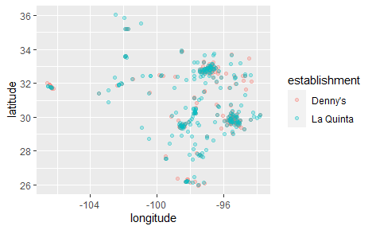

```r
dn_lq2 <- dn_lq %>%
  filter(state == "TX")

ggplot(dn_lq2, mapping = aes(x = longitude, y = latitude, color = establishment)) +
  geom_point(alpha = 0.3)
```

Mitch Hedberg’s joke appears to hold less well in Texas. There are manny La Quintas that are not near a Denny’s. …